# Analyzing and Visualizing Data

Data analyszing is the next step taken after data cleaning. This is done to provide meaningful insights to the WeRateDogs dataset

### What is the most popular tweet source?

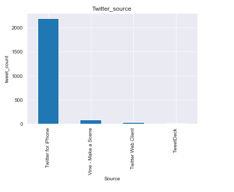

From the analysis above, it is shown that there are four major tweet sources which are `Twitter for Iphone`, `Vine - Make a Scene`, `Twitter Web Client`and `TweetDeck`. It also shows that over 90% users make use of 'Twitter for Iphone' with the value of 2191 users while less than 10% of users comprises of the other tweet sources 134 users.

### What is the most popular dog breed and the least popular dog breed?

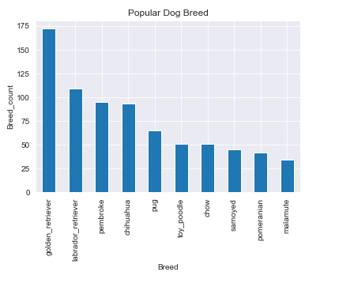

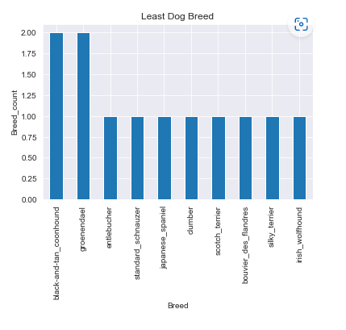

The popular dog breed in this dataset is **golden_retriever** follwed closely by **labrador_retriever**, **pembroke**, **chihuahua**. While the least dog breed by popularity are **irish_wolfhound**, **silky_terrier**, **bouvier_des_flandres** among others

### What is the correlation between favorite_counts and retweets

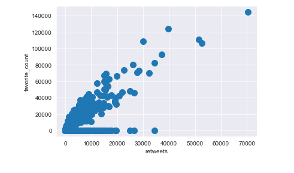

From the graph above, it shows that there is a positive correlation (0.801537359129741) between the number of favorite_counts and retweet. Each post made is likely to reach a wider audence by the number of likes and retweets. Though the proportion of favoutrit count is highr than that of the retweets.

### What is most popular dog name?

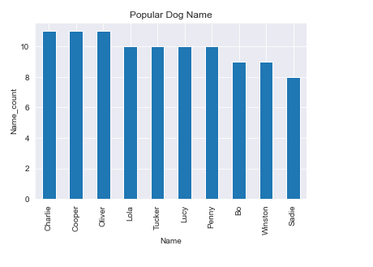

The above analysis shows that **charlie**, **cooper**, **oliver** are the most popular dog name

### What breed has the highest rating?

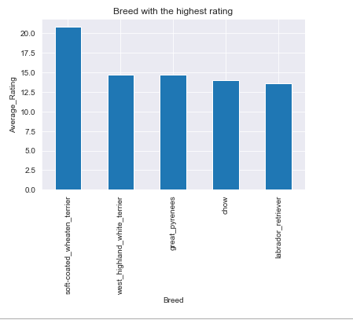

This analysis, shows that **soft-coated_wheaten_terrier**, is the breed with the average highest rating.

### What is the average retweeted and least retweeted dog breed?

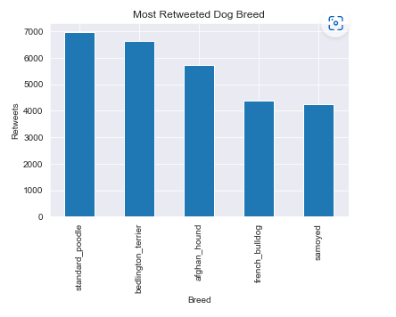

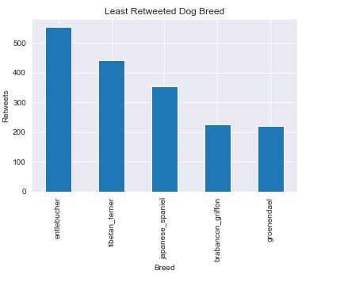

The bar chart above shows that, the top averge retweeted dog breeds are the **standard_poodle**, **bedlington_terrier**, **afghan_hound**, **french_bulldog** while the least retweeted dog breeds are **groenendael**, **brabancon_griffon**, **japanese_spaniel**

### What is the average liked dog breed?

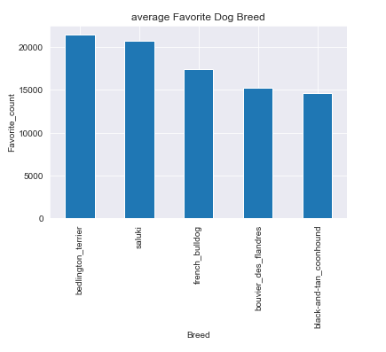

**bedlington_terrier**, **saluki**, **french_bulldog** are the breeds with the highest average favorite_counts

### What is the top dog stages

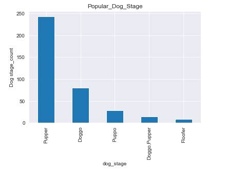

From the above analysis, it shows that **pupper** is the most common dog stage